# STAT 230

February 16, 2017

# Still more on regression

## Body fat data

```r
library(MASS)
b <- read.csv("http://www.stat.yale.edu/~jtc5/STAT230/data/bodyfat-252.csv")
# b250 <- read.csv("http://www.stat.yale.edu/~jtc5/STAT230/data/bodyfat.csv")
nrow(b)
```

```
## [1] 252
```

Next I’d like to add row names to the data frame. Let’s make a vector of row names that looks like r1, r2, …, r252.

```r
rownames(b) <- paste0("r",1:252)
# An aside on how the "paste" function works:
paste("I like stat", "230")
```

```
## [1] "I like stat 230"
```

```r
paste("I like stat", "230", sep="")
```

```
## [1] "I like stat230"
```

```r
paste0("I like stat", "230")
```

```
## [1] "I like stat230"
```

Take a quick look at scatterplots of all pairs of variables:

```r
dim(b)
```

```
## [1] 252  14
```

```r
head(b)
```

```
##      bf age weight height neck chest abdomen   hip thigh knee ankle biceps
## r1 12.3  23 154.25  67.75 36.2  93.1    85.2  94.5  59.0 37.3  21.9   32.0
## r2  6.1  22 173.25  72.25 38.5  93.6    83.0  98.7  58.7 37.3  23.4   30.5
## r3 25.3  22 154.00  66.25 34.0  95.8    87.9  99.2  59.6 38.9  24.0   28.8
## r4 10.4  26 184.75  72.25 37.4 101.8    86.4 101.2  60.1 37.3  22.8   32.4
## r5 28.7  24 184.25  71.25 34.4  97.3   100.0 101.9  63.2 42.2  24.0   32.2
## r6 20.9  24 210.25  74.75 39.0 104.5    94.4 107.8  66.0 42.0  25.6   35.7
##    forearm wrist
## r1    27.4  17.1
## r2    28.9  18.2
## r3    25.2  16.6
## r4    29.4  18.2
## r5    27.7  17.7
## r6    30.6  18.8
```

```r
names(b)
```

```
##  [1] "bf"      "age"     "weight"  "height"  "neck"    "chest"   "abdomen"
##  [8] "hip"     "thigh"   "knee"    "ankle"   "biceps"  "forearm" "wrist"
```

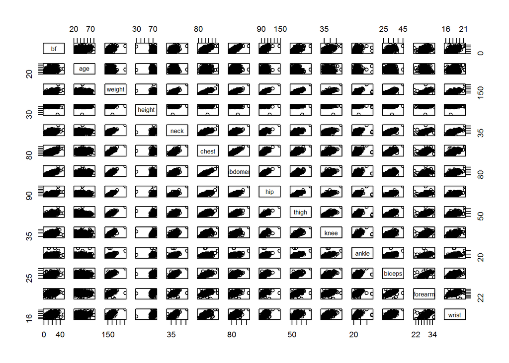

```r
plot(b)
```

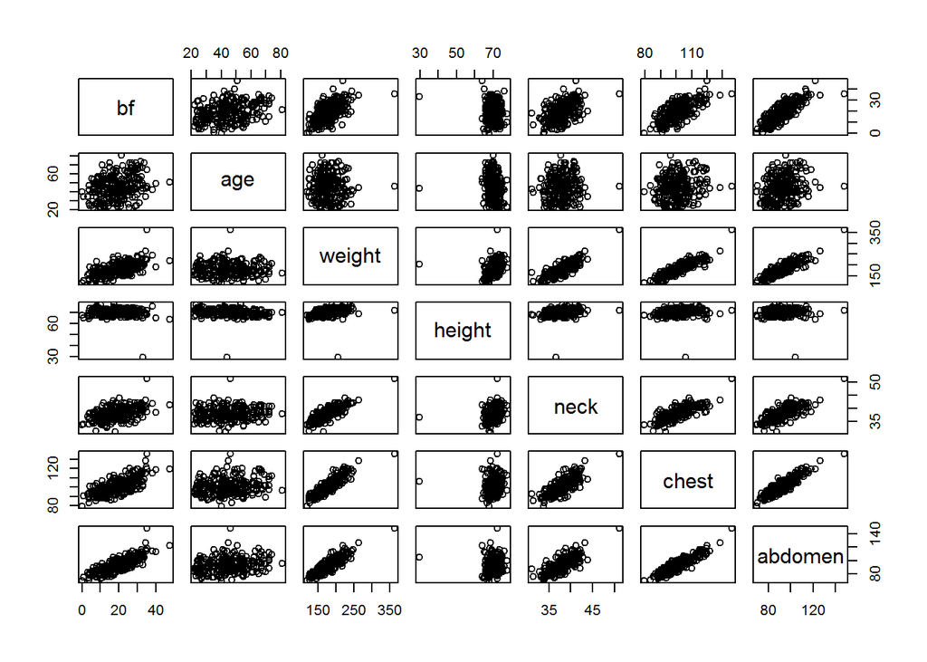

```r
plot(b[1:7])
```

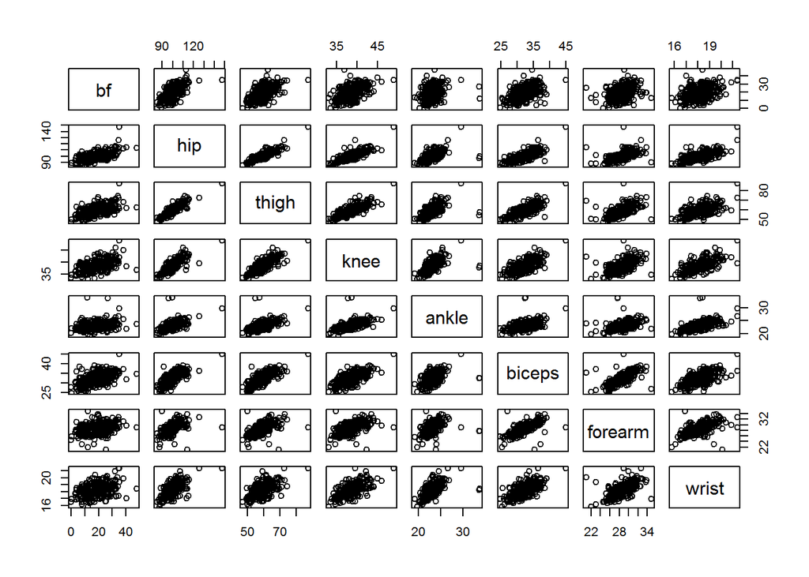

```r
plot(b[c(1,8:14)])
```

There is a person in the data with an very low value of height. Let’s see where this person falls in all of the scatterplots by coloring the corresponding point red, and making the other points mostly transparent:

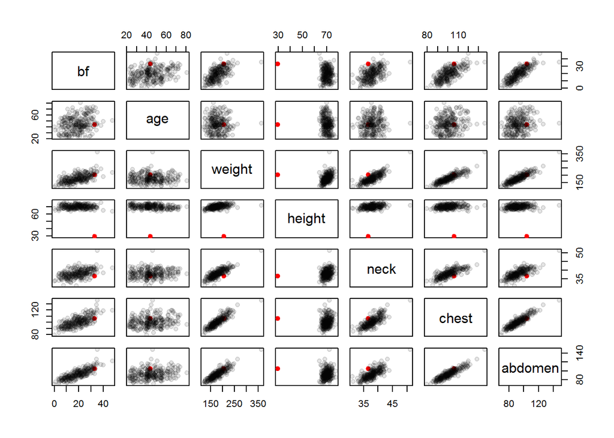

```r
n <- nrow(b)
i <- which(b$height < 60)
mycol <- rgb(rep(0,n),rep(0,n),rep(0,n),rep(0.1,n))
mycol[i] <- "red"
plot(b[1:7], col=mycol, pch=19)
```

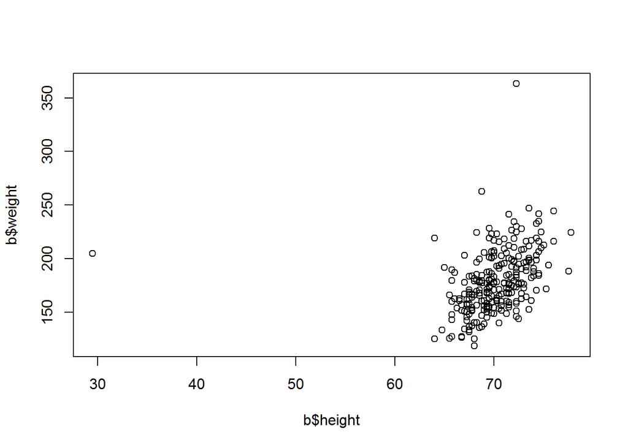

```
## integer(0)
```

```r
plot(b$weight ~ b$height)
identify(b$weight ~ b$height)
```

For now just remove person 42.

```r
b <- b[-i,]
dim(b)
```

```
## [1] 251  14
```

```r
n <- nrow(b)
```

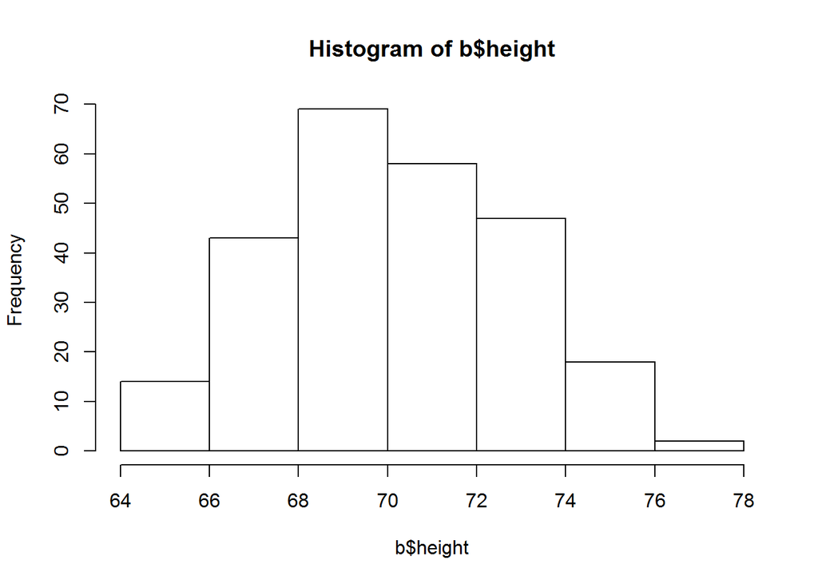

```r
# View(b)
hist(b$height)
```

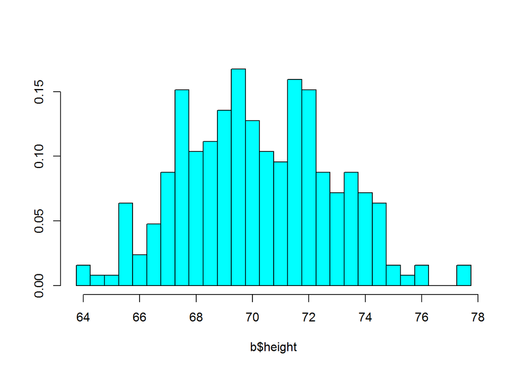

```r
      # I kind of like truehist for histograms. It's in the MASS library.
      truehist(b$height, h=.5, x0 = .25)
```

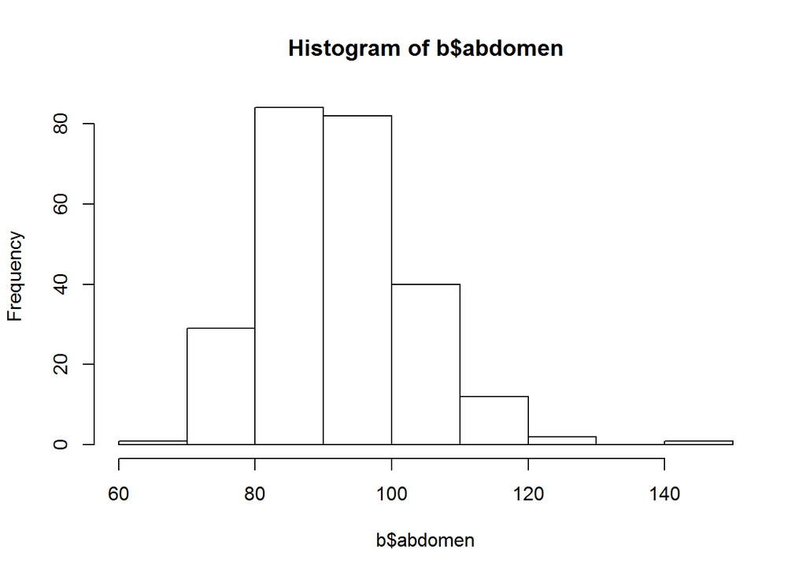

```r
hist(b$abdomen)
```

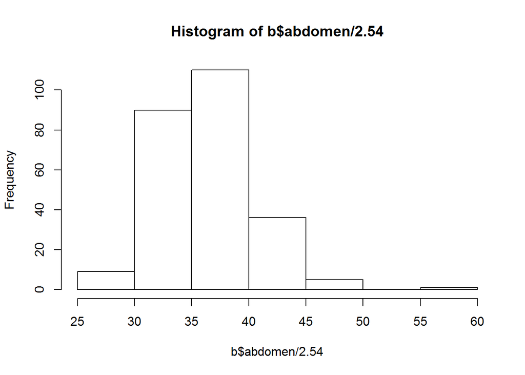

```r
hist(b$abdomen/2.54)
```

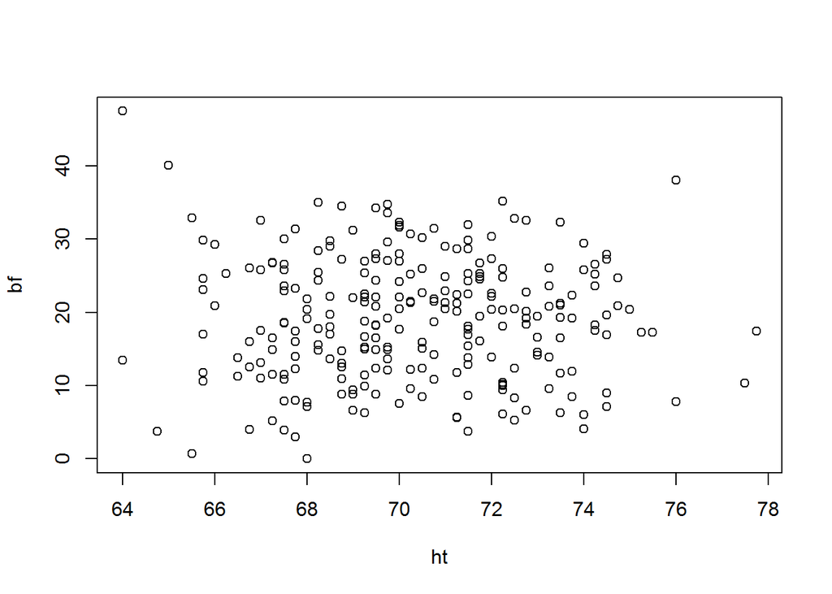

```r
bf = b$bf
ht = b$height
ab = b$abdomen/2.54

plot(bf ~ ht)
```

```r
cor(bf, ht)
```

```
## [1] -0.02338427
```

```r
lmh = lm(bf ~ ht)
summary(lmh)
```

```
##
## Call:
## lm(formula = bf ~ ht)
##
## Residuals:
##     Min      1Q  Median      3Q     Max
## -19.268  -6.697   0.286   6.162  27.933
##
## Coefficients:
##             Estimate Std. Error t value Pr(>|t|)
## (Intercept)  24.3412    14.2206   1.712   0.0882 .
## ht           -0.0746     0.2021  -0.369   0.7124
## ---
## Signif. codes:  0 '***' 0.001 '**' 0.01 '*' 0.05 '.' 0.1 ' ' 1
##
## Residual standard error: 8.355 on 249 degrees of freedom
## Multiple R-squared:  0.0005468,  Adjusted R-squared:  -0.003467
## F-statistic: 0.1362 on 1 and 249 DF,  p-value: 0.7124
```

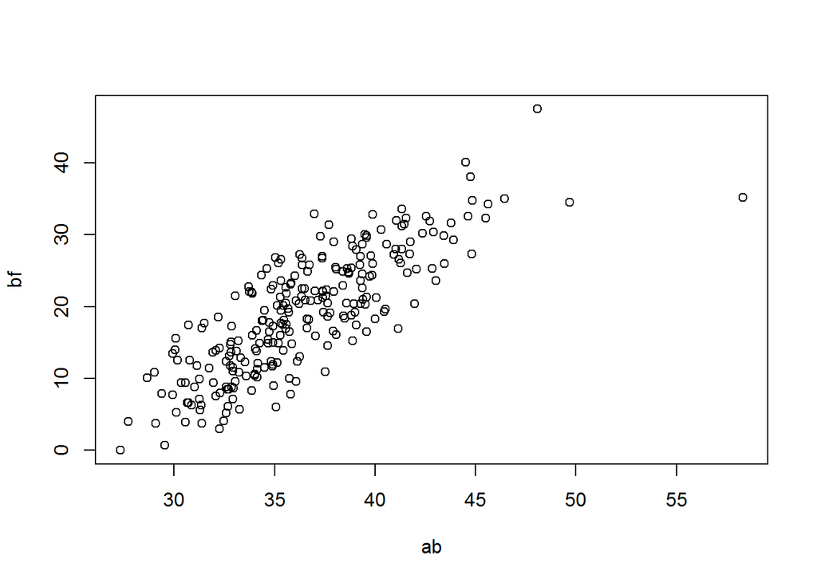

```r
# ^^ not surprising; it's not true that taller people have systematically
# less or more percent bodyfat...

plot(bf ~ ab)
```

```r
lma = lm(bf ~ ab)
summary(lma)
```

```
##
## Call:
## lm(formula = bf ~ ab)
##
## Residuals:
##      Min       1Q   Median       3Q      Max
## -18.8478  -3.7457   0.0445   3.3579  12.9295
##
## Coefficients:
##              Estimate Std. Error t value Pr(>|t|)
## (Intercept) -39.06753    2.66157  -14.68   <2e-16 ***
## ab            1.59698    0.07259   22.00   <2e-16 ***
## ---
## Signif. codes:  0 '***' 0.001 '**' 0.01 '*' 0.05 '.' 0.1 ' ' 1
##
## Residual standard error: 4.871 on 249 degrees of freedom
## Multiple R-squared:  0.6603, Adjusted R-squared:  0.6589
## F-statistic:   484 on 1 and 249 DF,  p-value: < 2.2e-16
```

```r
lmha = lm(bf ~ ht + ab)
summary(lmha)
```

```
##
## Call:
## lm(formula = bf ~ ht + ab)
##
## Residuals:
##      Min       1Q   Median       3Q      Max
## -19.2298  -3.5271  -0.0304   3.2513  10.0380
##
## Coefficients:
##             Estimate Std. Error t value Pr(>|t|)
## (Intercept)  0.08251    7.95579   0.010    0.992
## ht          -0.59308    0.11425  -5.191 4.36e-07 ***
## ab           1.66699    0.07038  23.685  < 2e-16 ***
## ---
## Signif. codes:  0 '***' 0.001 '**' 0.01 '*' 0.05 '.' 0.1 ' ' 1
##
## Residual standard error: 4.635 on 248 degrees of freedom
## Multiple R-squared:  0.6936, Adjusted R-squared:  0.6911
## F-statistic: 280.7 on 2 and 248 DF,  p-value: < 2.2e-16
```

`ht` was not useful by itself in predicting `bf`, but when `ab` is also in the model, `ht` becomes useful (statistically significant, in any case). If we fix a value for `ab` (or restrict it to a narrow range), then ht becomes useful in predicting bf.

Let’s see if we can visualize this a bit. We’ll plot subsets of the points having restricted ranges for `ab`, and see if the relationship between `bf` and `ht` tends to have negative slope.

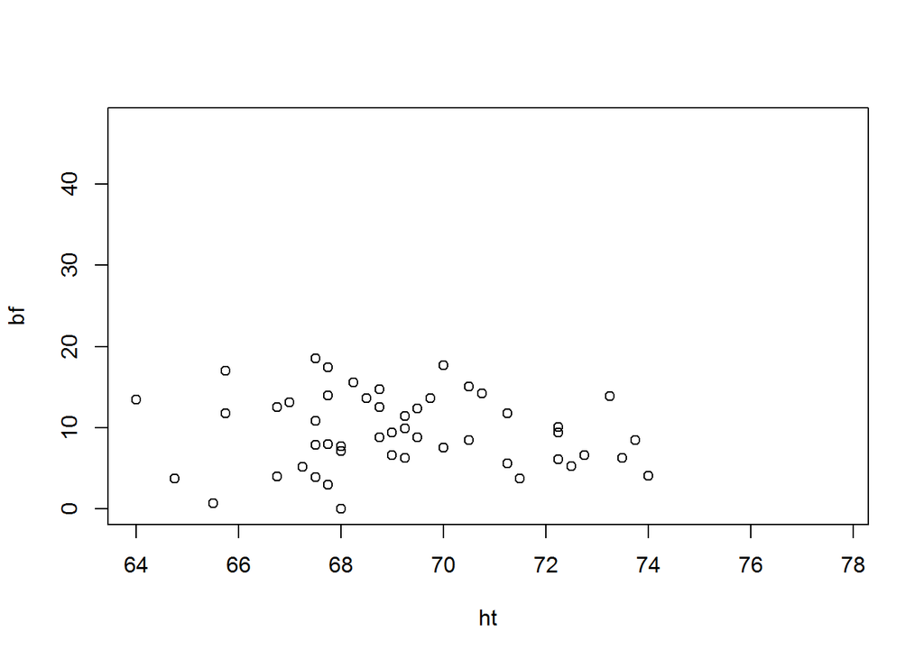

```r
qs <- quantile(ab, seq(0,1,by=.2))
ii <- which(ab >= qs[1] & ab <= qs[2])
plot(bf ~ ht, type="n")
points(bf[ii] ~ ht[ii])
```

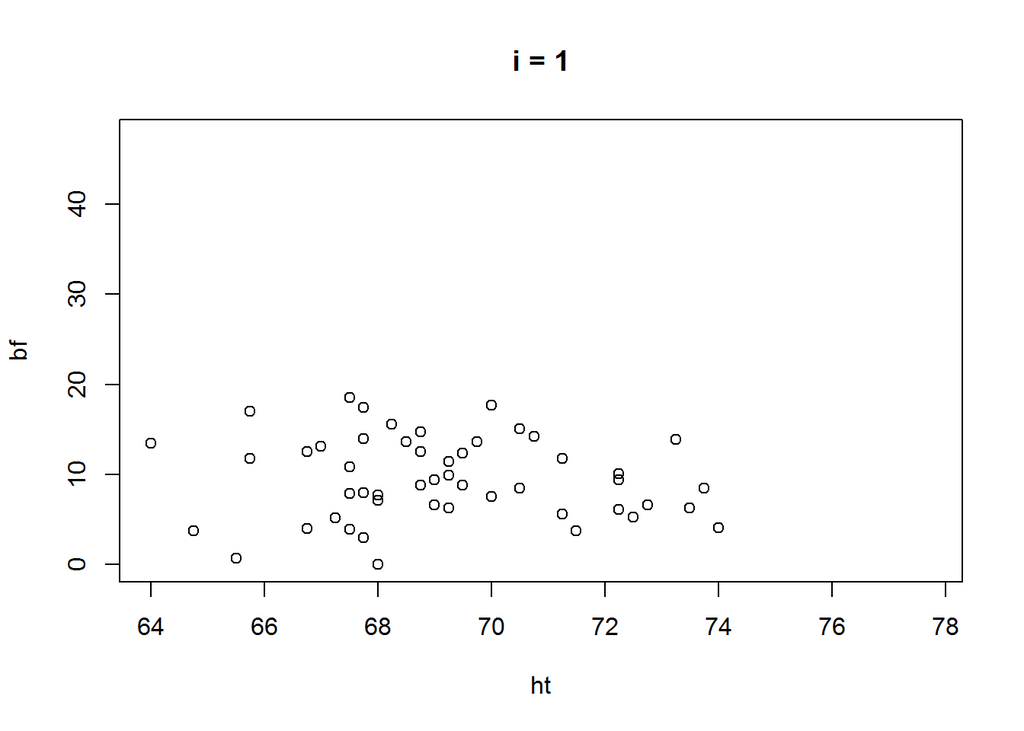

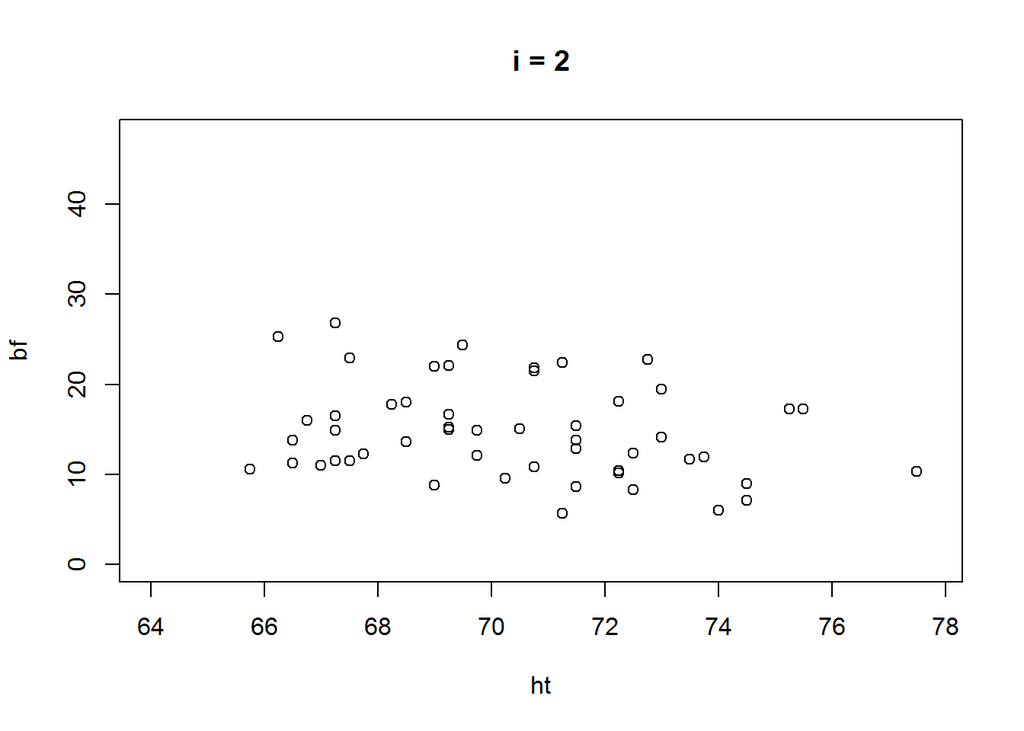

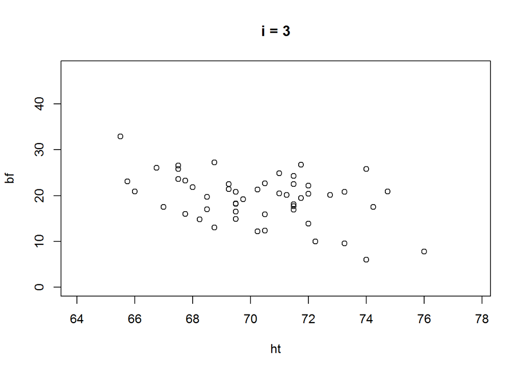

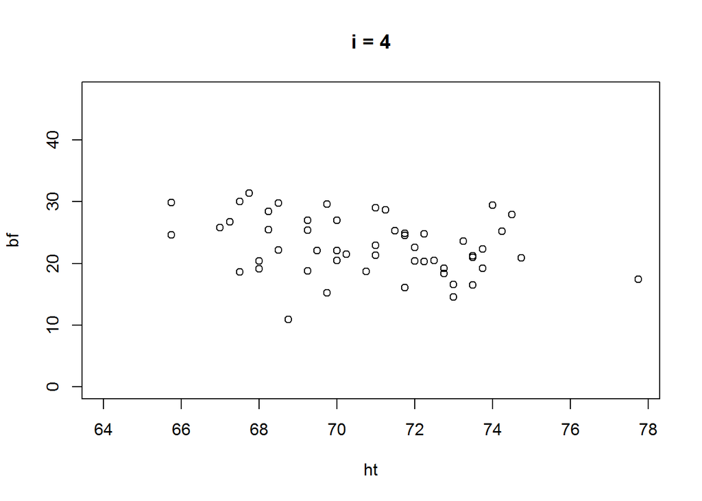

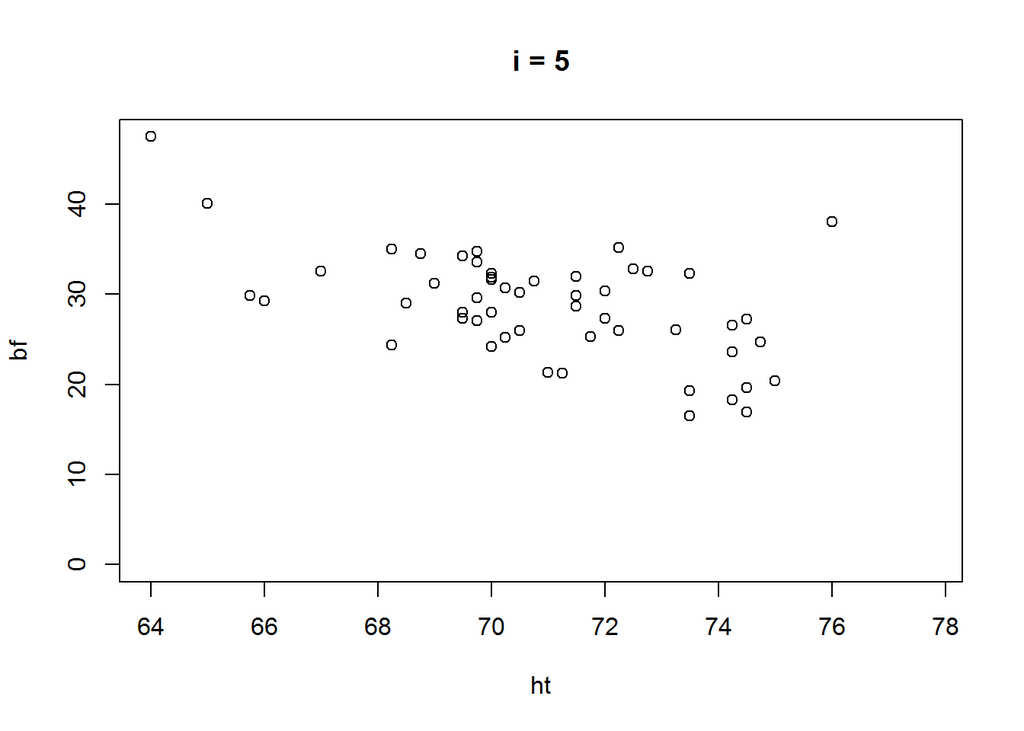

```r
for(i in 1:(length(qs)-1)){
  ii <- which(ab >= qs[i] & ab <= qs[i+1])
  plot(bf ~ ht, type="n", main=paste("i =",i))
  points(bf[ii] ~ ht[ii])
}
```

In preparation to study model selection, let’s run a big model including all columns:

```r
mall <- lm(bf ~ ., data=b)
mall
```

```
##
## Call:
## lm(formula = bf ~ ., data = b)
##
## Coefficients:
## (Intercept)          age       weight       height         neck
##  -20.492266     0.062126    -0.093621    -0.044552    -0.463918
##       chest      abdomen          hip        thigh         knee
##   -0.019125     0.959094    -0.205217     0.240235     0.006447
##       ankle       biceps      forearm        wrist
##    0.177386     0.185049     0.451047    -1.618680
```

```r
summary(mall)
```

```
##
## Call:
## lm(formula = bf ~ ., data = b)
##
## Residuals:
##      Min       1Q   Median       3Q      Max
## -11.1596  -2.8548  -0.0893   3.2070  10.0482
##
## Coefficients:
##               Estimate Std. Error t value Pr(>|t|)
## (Intercept) -20.492266  22.243941  -0.921  0.35786
## age           0.062126   0.032416   1.916  0.05650 .
## weight       -0.093621   0.062040  -1.509  0.13262
## height       -0.044552   0.178894  -0.249  0.80354
## neck         -0.463918   0.236396  -1.962  0.05088 .
## chest        -0.019125   0.103370  -0.185  0.85338
## abdomen       0.959094   0.090451  10.604  < 2e-16 ***
## hip          -0.205217   0.146878  -1.397  0.16366
## thigh         0.240235   0.146783   1.637  0.10303
## knee          0.006447   0.248244   0.026  0.97930
## ankle         0.177386   0.222858   0.796  0.42685
## biceps        0.185049   0.172728   1.071  0.28511
## forearm       0.451047   0.199624   2.259  0.02476 *
## wrist        -1.618680   0.536172  -3.019  0.00281 **
## ---
## Signif. codes:  0 '***' 0.001 '**' 0.01 '*' 0.05 '.' 0.1 ' ' 1
##
## Residual standard error: 4.314 on 237 degrees of freedom
## Multiple R-squared:  0.7463, Adjusted R-squared:  0.7324
## F-statistic: 53.64 on 13 and 237 DF,  p-value: < 2.2e-16
```

To get a quick impression of how well we can predict using the regression, we could do a plot that compares the actual `bf` values with the fitted values:

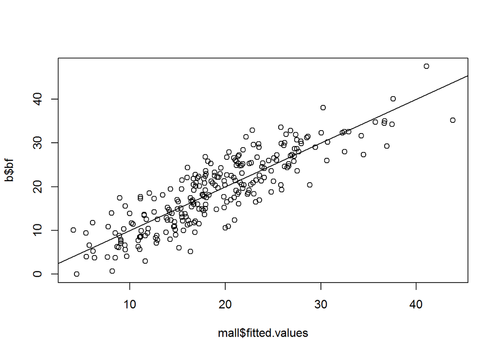

```r
plot(b$bf ~ mall$fitted.values)
abline(0,1)
```

```r
cor(b$bf, mall$fitted.values)
```

```
## [1] 0.86391
```

```r
cor(b$bf, mall$fitted.values)^2
```

```
## [1] 0.7463405
```

The last square correlation is the same as the “multiple R-squared” 0.7463 we see in `summary(mall)`.

NOTES

## Diagnostics for influential points and leverage

There’s a convenient function `influenceIndexPlot` (in the `car` library) that draws 4 plots that can be useful.

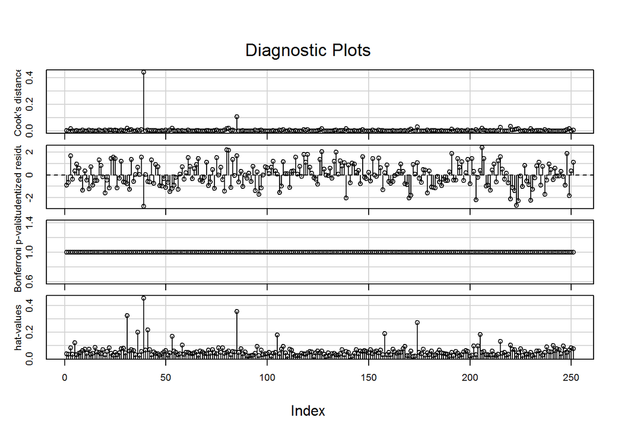

```r
library(car)
influenceIndexPlot(mall)
```

We can also calculate these quantities using functions in the standard R distribution. One of these is “Cook’s distance.” For each observation `i`, the `i`th Cook’s distance reflects how much the regression changes if we leave out the `i`th point versus if we include it.

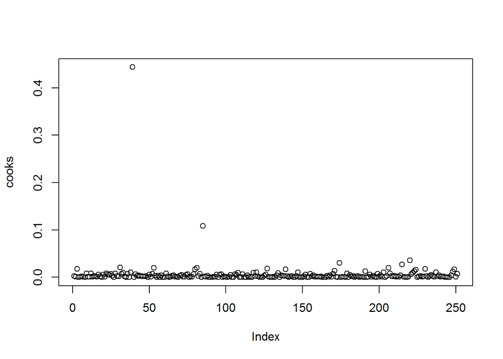

```r
cooks <- cooks.distance(mall)
plot(cooks)
```

```r
sort(cooks, decreasing = TRUE)[1:6]
```

```
##        r39        r86       r221       r175       r216        r31
## 0.44356630 0.10838299 0.03552789 0.03027519 0.02713953 0.02098862
```

```r
cookmaxs <- sort(cooks, decreasing = TRUE)[1:6]
which.max(cooks)
```

```
## r39
##  39
```

```r
pf(cookmaxs, df1 = 14, q = nrow(b)-14)
```

```
##        r39        r86       r221       r175       r216        r31
## 0.76962071 0.34892248 0.14786746 0.12955287 0.11824919 0.09516016
```

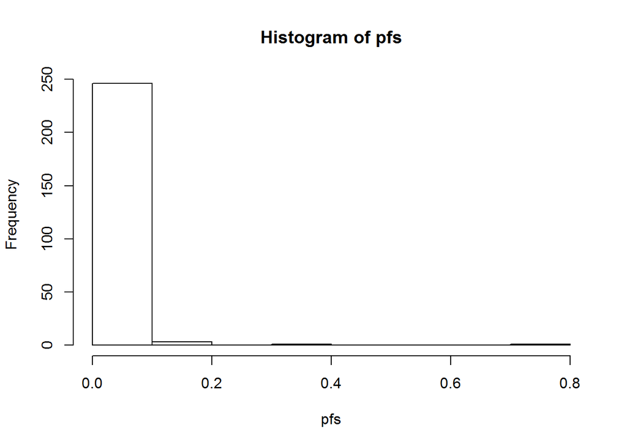

```r
pfs <- pf(cooks, df1 = 14, q = 252-14)
hist(pfs)
```

Rules of thumb:

From Kutner, Nachtsheim, Neter (2004) “Applied Linear Regression Models” p. 403 Look at percentiles of the Cook’s distances $D_i$ in the $F(p, n-p)$ distribution, where where $p$ is number of “x” variables in regression (plus 1 for the intercept) and $n$ is number of cases. If less than about 10 to 20%, not much influence. If near 50% or more, the $i$th case has major influence on the regression fit. So row r39 has major influence and we might want to remove this case.

“Leverage” is related but different. A point has high leverage if the fitted value $\hat{y}_i$ changes a lot if we increase or decrease $y_i$. This depends on the values of the explanatory variables for the `i`th case. If they are near the “center” of the distribution of these variables, the case has low leverage, whereas if they are far off, outlying values, the case has more leverage.

```r
hats <- hatvalues(mall)
sort(hats, decreasing = TRUE)[1:10]
```

```
##       r39       r86       r31      r175       r41       r36      r159
## 0.4572207 0.3572157 0.3228241 0.2717436 0.2158163 0.2003204 0.1878500
##      r206      r106       r54
## 0.1835383 0.1795301 0.1689922
```

```r
order(hatvalues(mall), decreasing = TRUE)[1:10]
```

```
##  [1]  39  85  31 174  41  36 158 205 105  53
```

```r
which.max(hatvalues(mall))
```

```
## r39
##  39
```

From Kutner, Nachtsheim, Neter (2004) “Applied Linear Regression Models” p. 399 A rule of thumb: 0.5 or more is very high leverage, .2 to .5 is moderate leverage But average leverage is p/n, so expect smaller leverage for larger sample sizes.

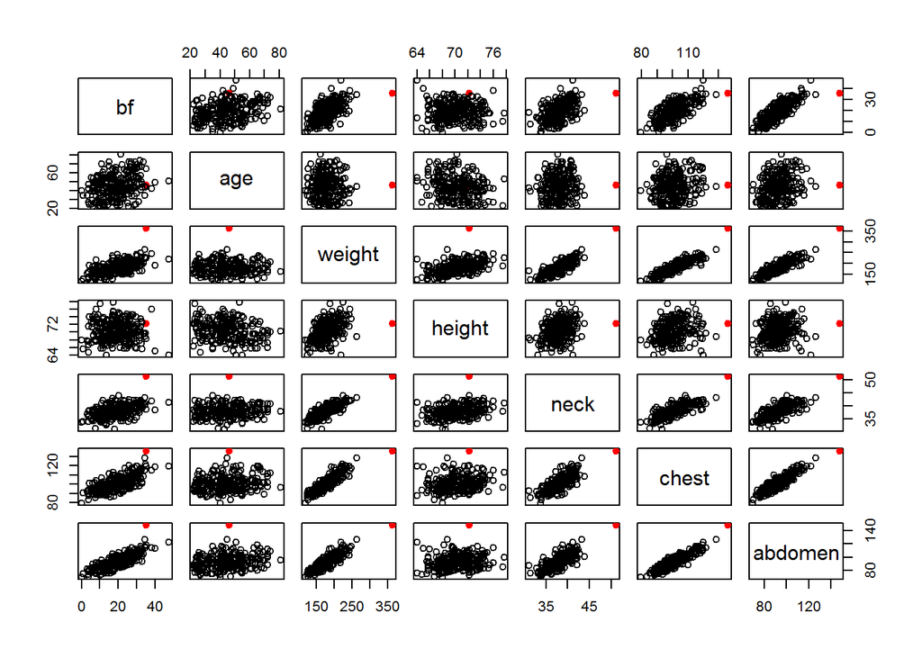

```r
n <- nrow(b)
ii <- 39
mypch=rep(1, n); mypch[ii] <- 19
mycol <- rep(1,n); mycol[ii] <- 2
plot(b[1:7], col=mycol, pch=mypch)
```

```r
b <- b[-ii,]
dim(b)
```

```
## [1] 250  14
```

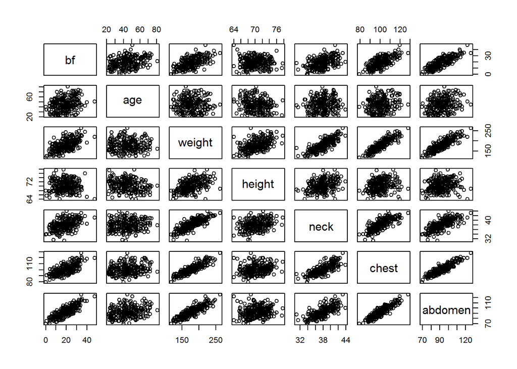

```r
plot(b[1:7])
```

Having removed r39 and r42, now at least visually there are no clear outliers, which is consistent with the results of the diagnostics.

We ended here to start the quiz! We’ll continue on model selection next time.